# NLP_Assignment_5_

## NLP Class Assignment 5

### Import Libraries

```python
import pandas as pd

# pandas settings
pd.set_option('display.max_rows', 100)
pd.set_option('display.max_columns', None)
pd.set_option('display.max_colwidth', 500)
```

```python
import pandas as pd
import nltk as nltk
import nltk.corpus
from nltk.text import Text
import re
import sys
from sklearn.feature_extraction.text import CountVectorizer
from sklearn.metrics import jaccard_score
from itertools import combinations
from nltk.tokenize import word_tokenize
from nltk.corpus import stopwords
import matplotlib.pyplot as plt
from nltk import ngrams
from spacy.lang.en.stop_words import STOP_WORDS
import pandas as pd
import matplotlib.pyplot as plt
from collections import Counter
from pandarallel import pandarallel
import multiprocessing
# Initialize pandarallel
pandarallel.initialize()
```

```
INFO: Pandarallel will run on 10 workers.
INFO: Pandarallel will use standard multiprocessing data transfer (pipe) to transfer data between the main process and workers.
```

```python
from pandarallel import pandarallel
import multiprocessing
num_cores = multiprocessing.cpu_count()
print(f"You have {num_cores} cores.")# Initialize pandarallel to use num_cores - 1
pandarallel.initialize(nb_workers=num_cores-1)
```

```
You have 10 cores.
INFO: Pandarallel will run on 10 workers.
INFO: Pandarallel will use standard multiprocessing data transfer (pipe) to transfer data between the main process and workers.
```

#### Read news data

```python
news_path = 'https://storage.googleapis.com/msca-bdp-data-open/news/nlp_a_5_news.json'
news_df = pd.read_json(news_path, orient='records', lines=True)

print(f'Sample contains {news_df.shape[0]:,.0f} news articles')
news_df.head(2)
```

```
Sample contains 10,012 news articles
```

|  | url | date | language | title | text |
| --- | --- | --- | --- | --- | --- |
| 0 | http://kokomoperspective.com/obituaries/jon-w-horton/article_b6ba8e1e-cb9c-11eb-9868-fb11b88b9778.html | 2021-06-13 | en | Jon W. Horton \| Obituaries \| kokomoperspective.com | Jon W. Horton \| Obituaries \| kokomoperspective.comYou have permission to edit this article. EditCloseSign Up Log In Dashboard LogoutMy Account Dashboard Profile Saved items LogoutCOVID-19Click here … |
| 1 | https://auto.economictimes.indiatimes.com/news/auto-components/birla-precision-to-ramp-up-capacity-to-tap-emerging-opportunities-in-india/81254902 | 2021-02-28 | en | Birla Precision to ramp up capacity to tap emerging opportunities in India, Auto News, ET Auto | Birla Precision to ramp up capacity to tap emerging opportunities in India, Auto News, ET Auto We have updated our terms and conditions and privacy policy Click "Continue" to accept and continue with … |

#### Read Tweets data

```python
tweets_path = 'https://storage.googleapis.com/msca-bdp-data-open/tweets/nlp_a_5_tweets.json'
tweets_df = pd.read_json(tweets_path, orient='records', lines=True)
print(f'Sample contains {tweets_df.shape[0]:,.0f} tweets')
tweets_df.head(2)
```

```
Sample contains 10,105 tweets
```

|  | id | lang | date | name | retweeted | text |
| --- | --- | --- | --- | --- | --- | --- |
| 0 | 1534565117614084096 | en | 2022-06-08 | Low Orbit Tourist 🌍📷 |  | Body &amp; Assembly - Halewood - United Kingdom\n🌍53.3504,-2.8352296,402m\n\nHalewood Body &amp; Assembly is a Jaguar Land Rover factory in Halewood, England, and forms the major part of the Halewood … |
| 1 | 1534565743429394439 | en | 2022-06-08 | CompleteCar.ie | RT | Land Rover Ireland has announced that the new Range Rover Sport starts at €114,150, now on @completecar:\n\nhttps://t.co/TjGUkL3FYr https://t.co/QdVaEiJkjO |

```python
import spacy
from collections import Counter
```

```python
# loading particular nlp model
nlp = spacy.load("en_core_web_md")

type(nlp)
```

```
spacy.lang.en.English
```

# Data Cleaning

We remove URLs, mentions, hashtags, and newline characters for analysis purpose as we did before. Moreoever, we also convert words that are entirely in uppercase to lowercase, because we saw some netcitizens used uppercase words to emphasize their emtions and feeling, eg. they use "SHAMELESS" to express their disappointment. We think converting words that are entirely in uppercase to lowercase could avoid the model treating these words as proper nouns.

```python
import re
import spacy
import wordninja

def lowercase_if_uppercase(match):
    # Convert matched word to lowercase
    word = match.group(0)
    return word.lower()


def clean_text(text):
    # Remove emojis
    emoji_pattern = re.compile(
        "["
        "\U0001F600-\U0001F64F"  # emoticons
        "\U0001F300-\U0001F5FF"  # symbols & pictographs
        "\U0001F680-\U0001F6FF"  # transport & map symbols
        "\U0001F1E0-\U0001F1FF"  # flags (iOS)
        "\U00002702-\U000027B0"
        "\U000024C2-\U0001F251"
        "\U0001F900-\U0001F9FF"  # Supplemental Symbols and Pictographs
        "\U0001FA00-\U0001FA6F"  # Chess Symbols
        "\U0001FA70-\U0001FAFF"  # Symbols and Pictographs Extended-A
        "\U00002600-\U000026FF"  # Miscellaneous Symbols
        "\U00002700-\U000027BF"  # Dingbats
        "]+", flags=re.UNICODE)
    text = emoji_pattern.sub(r'', text)

    # Remove URLs
    text = re.sub(r'http\S+|www\.\S+', ' ', text)

    # Remove mentions
    text = re.sub(r'@\w+', ' ', text)

    # Remove entire hashtags (both symbol and text)
    text = re.sub(r'#\w+', ' ', text)

    # Remove newline characters
    text = text.replace('\n', ' ')

    # Convert words that are entirely in uppercase to lowercase
    # This step should come before removing all-uppercase words to ensure
    # meaningful uppercase words are preserved in lowercase
    text = re.sub(r'\b[A-Z]{2,}\b', lowercase_if_uppercase, text)

    # Lemmatization
    doc = nlp(text)
    lemmatized_text = " ".join([token.lemma_ for token in doc])

    return lemmatized_text.strip()

# Example usage
text = "team awarded new Land Rover in Louisville | News | wdrb.com   Skip to main contentYou have permission to edit this article. EditClose"
cleaned_text = clean_text(text)
print(cleaned_text)
```

```
team award new Land Rover in Louisville | News | wdrb.com    Skip to main contentyou have permission to edit this article . EditClose
```

```python
tweets_df['cleaned text'] = tweets_df['text'].parallel_apply(clean_text)
```

```python
news_df['cleaned text'] = news_df['text'].parallel_apply(clean_text)
```

```python
news_df['cleaned title'] = news_df['title'].parallel_apply(clean_text)
```

## Extract entities without sentence segmentation for Tweets

```python
def extract_entities(text):
    doc = nlp(text)
    return [(ent.text, ent.label_) for ent in doc.ents]
```

```python
# Use pandarallel for parallel apply
tweets_df['entities'] = tweets_df['cleaned text'].parallel_apply(extract_entities)
```

```python
tweets_df.head(50)
```

|  | id | lang | date | name | retweeted | text | cleaned text | entities |
| --- | --- | --- | --- | --- | --- | --- | --- | --- |
| 0 | 1534565117614084096 | en | 2022-06-08 | Low Orbit Tourist 🌍📷 |  | Body &amp; Assembly - Halewood - United Kingdom\n🌍53.3504,-2.8352296,402m\n\nHalewood Body &amp; Assembly is a Jaguar Land Rover factory in Halewood, England, and forms the major part of the Halewood … | body & amp ; Assembly - Halewood - United Kingdom 53.3504,-2.8352296,402 m Halewood Body & amp ; Assembly be a Jaguar Land Rover factory in Halewood , England , and form the major part of the Halewood… | [(body & amp, ORG), (Assembly - Halewood - United Kingdom, ORG), (53.3504,-2.8352296,402 m, QUANTITY), (Halewood Body & amp, ORG), (Assembly, ORG), (Jaguar Land Rover, ORG), (Halewood, GPE), (England,… |
| 1 | 1534565743429394439 | en | 2022-06-08 | CompleteCar.ie | RT | Land Rover Ireland has announced that the new Range Rover Sport starts at €114,150, now on @completecar:\n\nhttps://t.co/TjGUkL3FYr https://t.co/QdVaEiJkjO | Land Rover Ireland have announce that the new Range Rover Sport start at € 114,150 , now on : | [(Land Rover Ireland, ORG), (Range Rover Sport, ORG), (114,150, MONEY)] |
| 2 | 1529341557580652545 | en | 2022-05-25 | Exmoor Trim |  | New Land Rover Range Rover Hits Top Speed With Ease On Autobahn\n\nhttps://t.co/19QOgAIu3v | New Land Rover Range Rover Hits Top Speed with ease on Autobahn | [(New Land Rover Range Rover Hits Top Speed, ORG), (Autobahn, FAC)] |
| 3 | 1542790343535755264 | en | 2022-07-01 | Land Rover UK |  | @BeckyWatts1 Hi, thank you for your post. I am sorry to learn of your retailer experience, however when order slots are available they will be presented to the retailer, and it is at their discretion … | hi , thank you for your post . I be sorry to learn of your retailer experience , however when order slot be available they will be present to the retailer , and it be at their discretion which vehicle… | [(Dan - Land, PERSON)] |
| 4 | 1516732103370493954 | en | 2022-04-20 | Sussexes❤️👑🐼🌸 |  | @cofvefe917 @Mackingday No this was during the Land Rover driving challenge. | no this be during the Land Rover drive challenge . | [(Land Rover, ORG)] |
| 5 | 1526492942512312320 | en | 2022-05-17 | Mat Rees | RT | Just watched this Land Rover toss piles of rubbish - balloons, empty alcohol bottles, empty takeaway containers - out the window on Brunswick Sq in broad daylight and then drive off.\n\nFeel free to g… | just watch this Land Rover toss pile of rubbish - balloon , empty alcohol bottle , empty takeaway container - out the window on Brunswick Sq in broad daylight and then drive off . feel free to give Ma… | [(Land Rover, PRODUCT), (Brunswick Sq, FAC), (Mainstream Property Services, ORG)] |
| 6 | 1526493037806878720 | en | 2022-05-17 | Baron Woke of Carlsberg 🇺🇦 | RT | Just watched this Land Rover toss piles of rubbish - balloons, empty alcohol bottles, empty takeaway containers - out the window on Brunswick Sq in broad daylight and then drive off.\n\nFeel free to g… | just watch this Land Rover toss pile of rubbish - balloon , empty alcohol bottle , empty takeaway container - out the window on Brunswick Sq in broad daylight and then drive off . feel free to give Ma… | [(Land Rover, PRODUCT), (Brunswick Sq, FAC), (Mainstream Property Services, ORG)] |
| 7 | 1552029227146530817 | en | 2022-07-26 | Ngwati Francis | RT | 'Parts are not available'\n\n'Nissans are not good cars'\n\n'Mazda diesels are problematic'\n\n'Usinunue Land Rover'\n\nJust Know how to maintain a car na uache mambo mingi! | ' part be not available ' ' Nissans be not good car ' ' Mazda diesel be problematic ' ' Usinunue Land Rover ' just know how to maintain a car na uache mambo mingi ! | [(Nissans, ORG), (Mazda, ORG), (Usinunue Land Rover ', ORG), (uache, ORG), (mambo mingi, PERSON)] |
| 8 | 1545395541416321026 | en | 2022-07-08 | Olu Femi |  | Genuinely not a car person but that Land Rover defender is haunting me | genuinely not a car person but that Land Rover defender be haunt I | [(Land Rover, ORG)] |
| 9 | 1536673512588558339 | en | 2022-06-14 | BornBackpacker | RT | 🤣🤣🤣\nThe first "Tasty &amp; that's it" restaurants opened in Russia yesterday to replace McDonald's🍔🍟\n\nIt is also reported that Audi, BMW, Lexus, Porsche, Jaguar, Land Rover, Lamborghini and Bentley… | the first " Tasty & amp ; that be it " restaurant open in Russia yesterday to replace McDonald 's it be also report that Audi , bmw , Lexus , Porsche , Jaguar , Land Rover , Lamborghini and Bentley sh… | [(first, ORDINAL), (Tasty & amp, WORK_OF_ART), (Russia, GPE), (yesterday, DATE), (McDonald, ORG), (Audi, ORG), (bmw, ORG), (Lexus, ORG), (Porsche, ORG), (Jaguar, ORG), (Land Rover, ORG), (Lamborghini,… |
| 10 | 1542104985193762816 | en | 2022-06-29 | Motor Mounts Car and Truck |  | LAND ROVER DISCOVERY DEFENDER Td5 ENGINE MOUNT MOUNTING SET x2 KKB500750 https://t.co/3iXCgQe20w eBay https://t.co/ox1tPgUVmm | land rover discovery defender td5 engine mount mount set x2 KKB500750 eBay | [(discovery, PRODUCT), (KKB500750, PRODUCT), (eBay, ORG)] |
| 11 | 1508359111183900673 | en | 2022-03-28 | Joy Ijerebi |  | Alhaji TEKNO is fond of everything made by Land Rover brand | Alhaji tekno be fond of everything make by Land Rover brand | [(Alhaji tekno, PERSON), (Land Rover, ORG)] |
| 12 | 1487786414414745601 | en | 2022-01-30 | Ian Dickinson | RT | For Sale\n2011 Land Rover Discovery Commercial SDV6. Tow bar, Full leather,Sat Nav,Fridge, Alloys, spare wheel etc,Full seat covers\nFull Service history, no expense spared.\n138k miles. \n£14,500 ONO… | for Sale 2011 Land Rover Discovery Commercial SDV6 . tow bar , full leather , Sat Nav , Fridge , Alloys , spare wheel etc , full seat cover full Service history , no expense spare . 138k mile . £ 14,5… | [(Sale 2011, DATE), (SDV6, PERSON), (Sat Nav, WORK_OF_ART), (Fridge, ORG), (Alloys, ORG), (138k mile, QUANTITY)] |
| 13 | 1487787454648229894 | en | 2022-01-30 | Bernardo Pinheiro Pereira | RT | 👊 Fine front-running performance\n\nAutumn Pride makes all to capture the Land Rover Handicap in fine style for Helal Alalawi &amp; Bernardo Pinheiro \n\n@AlTayerMotorsLandRoverUAE #JLRRaceMeeting #Dr… | fine front - run performance Autumn Pride make all to capture the Land Rover Handicap in fine style for Helal Alalawi & amp ; Bernardo Pinheiro | [(Autumn Pride, WORK_OF_ART), (Helal Alalawi & amp, FAC), (Bernardo Pinheiro, PERSON)] |
| 14 | 1554371215619674114 | en | 2022-08-02 | Ruthless Focus_ |  | READY TO SHIP ON ORDER\n∎Landrover RR Evoque 2015\n∎2000cc\n∎Petrol\n∎237Bhp \n∎86,000Kms\n∎Hill Start Assist\n∎Traction Control System\n∎Trailer Stability Assist\n∎Electronic Park Brake\n∎Land Rover … | ready to ship on order ∎Landrover rr Evoque 2015 ∎2000cc ∎Petrol ∎237bhp ∎86,000Kms ∎Hill Start Assist ∎traction Control System ∎Trailer Stability Assist ∎Electronic Park Brake ∎Land Rover Service His… | [(Evoque, ORG), (2015, DATE), (Rover Service History, ORG)] |
| 15 | 1542775815905099777 | en | 2022-07-01 | P Cornish |  | @Icarus_Flies @KirstieMAllsopp Did you miss the Mercedes G Wagon, the Land Rover Discovery and the Jaguar i-Pace? | do you miss the Mercedes G Wagon , the Land Rover Discovery and the Jaguar i - Pace ? | [(Discovery, PRODUCT)] |
| 16 | 1542784033628856322 | en | 2022-07-01 | Tom |  | M6 near Penrith, can’t see Land Rover doing anything like this with the current gen Defender. https://t.co/xbAXXGAq4B | M6 near Penrith , can not see Land Rover do anything like this with the current gen Defender . | [(Penrith, GPE), (Land Rover, ORG)] |
| 17 | 1554373907527999490 | en | 2022-08-02 | 🇬🇧Josephine⚒ | RT | The annual Rural Crime Report said farm vehicles are the top target for organised gangs while Land Rover Defenders, quad bikes and trailers are being stolen in record numbers.\nIS ANYONE SURPRISED WIT… | the annual Rural Crime Report say farm vehicle be the top target for organised gang while Land Rover Defenders , quad bike and trailer be be steal in record number . be anyone surprised with what have… | [(annual, DATE), (Rural Crime Report, EVENT), (Land Rover Defenders, ORG)] |
| 18 | 1554375221477609474 | en | 2022-08-02 | 🐝 |  | The defender 110 was conceived to qualify as a bus to avoid taxes - Apparently the great Land Rover didn't like paying taxes back 😂😂 \n\nAnyway before the LX 570 this was my favourite "off-road" I lik… | the defender 110 be conceive to qualify as a bus to avoid taxis - apparently the great Land Rover do not like pay taxis back anyway before the lx 570 this be my favourite " off - road " I like to call… | [(110, CARDINAL), (Land Rover, ORG), (chuuma, PERSON)] |
| 19 | 1551115236261990401 | en | 2022-07-24 | Collecting Cars |  | 🇬🇧 *ENDING SOON*\n\nThis Land Rover Defender 90 D250 X-Dynamic S is a nearly-new example of the desirable modern 4x4, offered in ‘as-new’ condition throughout.\n\nDetails: https://t.co/jOcAo4P0Oz\n\n#… | * end soon * this Land Rover Defender 90 D250 x - dynamic S be a nearly - new example of the desirable modern 4x4 , offer in ' as - new ' condition throughout . detail : | [(90 D250, CARDINAL), (4x4, PRODUCT)] |
| 20 | 1491874633443786778 | en | 2022-02-10 | FBMyNextCar |  | #news #BMW4Series #Buick #BuickEncore #BuickEnvision Kia And Buick Top Reliability Study For 2022, RAM And Land Rover Finish Last With Most Issues https://t.co/kRUAYJWbDV | Kia and Buick Top Reliability Study for 2022 , ram and Land Rover Finish last with Most issue | [(Kia, ORG), (Buick Top Reliability Study, ORG), (2022, DATE), (Land Rover Finish, ORG)] |
| 21 | 1545094590705057794 | en | 2022-07-07 | Gajohr | RT | #TataMotors\nJaguar Land Rover Reports Q1 FY2022-23 Retail Sales https://t.co/jaTRHRASdj | Jaguar Land Rover Reports Q1 fy2022 - 23 Retail Sales | [(Jaguar Land Rover Reports, ORG)] |
| 22 | 1536674758011588609 | en | 2022-06-14 | kiprono kebenei | RT | DP Ruto gifted a UDA branded toy model of the president's ceremonial land rover. https://t.co/pxXBfwrDZG | dp Ruto gift a uda brand toy model of the president 's ceremonial land rover . | [(dp Ruto, PERSON)] |
| 23 | 1545403964572676097 | en | 2022-07-08 | Latest Govt Jobs INDIA USA UK |  | Check Tata Motors Group global wholesales data in Q1FY23 including Jaguar Land Rover – Details https://t.co/8osU7eIFTf | check Tata Motors Group global wholesales datum in Q1FY23 include Jaguar Land Rover – detail | [(Tata Motors Group, ORG), (Q1FY23, PERSON), (Jaguar Land Rover, ORG)] |
| 24 | 1490145873040269312 | en | 2022-02-06 | Don huynh |  | @PlaySnowRunner Will there be a 2020 Land Rover defender in snowrunner on console? | will there be a 2020 Land Rover defender in snowrunner on console ? | [(2020, DATE), (Land Rover, ORG)] |
| 25 | 1494607296596484103 | en | 2022-02-18 | Daniel |  | @ndagijerichie Land rover defender for me🔥😄 \nMeanwhile have you seen that Mercedes W13 for this F1 season...the engineers didn't sleep, eeh🙌🏿 | Land rover defender for I meanwhile have you see that Mercedes W13 for this f1 season ... the engineer do not sleep , eeh | [(Mercedes W13, ORG), (this f1 season, DATE)] |
| 26 | 1508365786498351106 | en | 2022-03-28 | Dilwar Khan | RT | #151515\n📍 He writes about a weekend spent repeatedly diving to the floor of the cottage he and other journalists were staying at as warplanes flew overhead and the sounds of artillery got closer and … | he write about a weekend spend repeatedly diving to the floor of the cottage he and other journalist be stay at as warplane fly overhead and the sound of artillery get close and close , and the 2007 L… | [(about a weekend, DATE), (2007, DATE)] |
| 27 | 1529350692195794945 | en | 2022-05-25 | Grilles Car Truck |  | LAND ROVER DISCOVERY L319 Front Bumper Radiator Grille DHB000274 2006 https://t.co/7Y634MoWpt eBay https://t.co/2G5Cmur5No | land rover discovery L319 Front Bumper Radiator Grille DHB000274 2006 eBay | [(L319, CARDINAL), (eBay, ORG)] |
| 28 | 1542786244190552065 | en | 2022-07-01 | Steve Maverick (💸, 💸) | RT | Land Rover never misses the target when it comes to the Range Rover! This new one is just amazing!\n\n📸 by wallacepjw (IG) https://t.co/awTyiF04YK | Land Rover never miss the target when it come to the Range Rover ! this new one be just amazing ! by wallacepjw ( ig ) | [(Range Rover, PRODUCT), (wallacepjw, PERSON)] |
| 29 | 1493788359407198209 | en | 2022-02-16 | Cars Motorcycles Vehicles |  | 2005 LAND ROVER DISCOVERY 3 TDV6 SPORT 7 SEATER SPARES OR REPAIR *NO RESERVE* https://t.co/JIOorHbYbI eBay | 2005 land rover discovery 3 TDV6 sport 7 seater spare or repair * no reserve * eBay | [(2005, DATE), (3, CARDINAL), (7, CARDINAL), (eBay, ORG)] |
| 30 | 1508377640507379716 | en | 2022-03-28 | Red Dragon | RT | So turns out The Duke &amp; Duchess of Cambridge on the land rover was actually at the request of the hosts in Jamaica. Once again another thing out of their control they are being blamed for. https:/… | so turn out the Duke & amp ; Duchess of Cambridge on the land rover be actually at the request of the host in Jamaica . once again another thing out of their control they be be blame for . | [(Duchess, CARDINAL), (Cambridge, GPE), (Jamaica, GPE)] |
| 31 | 1504675525041737736 | en | 2022-03-18 | Van Now |  | A Land Rover Defender has just been added on https://t.co/HAkEgh7Uaa. Don't miss out, click here to view: https://t.co/fbSGfwPuOU\n#vans #vansforsale #commercialvehicles #vannow #usedvansforsale #moto… | a Land Rover Defender have just be add on do not miss out , click here to view : | [(Land Rover Defender, ORG)] |
| 32 | 1526504997525065728 | en | 2022-05-17 | BILLY \| Castelroussin day |  | Un land rover dicovery sport M1 https://t.co/yhmrzcjiR1 | Un land rover dicovery sport M1 | [(M1, PRODUCT)] |
| 33 | 1487883014029803523 | en | 2022-01-30 | Jay Gatsby |  | @KatesPowerSuit This is one of my favorite Land Rover ads! 🥰🥰🥰 | this be one of my favorite Land Rover ad ! | [(Land Rover, ORG)] |
| 34 | 1534675886444007424 | en | 2022-06-08 | ラグビー動画まとめ |  | Land Rover announced as Worldwide Partner of Rugby World Cup 2021 https://t.co/9AJxRckzut | Land Rover announce as Worldwide Partner of Rugby World Cup 2021 | [(Land Rover, ORG), (Worldwide Partner of Rugby World Cup, ORG), (2021, DATE)] |
| 35 | 1526507322452877313 | en | 2022-05-17 | CSbungo | RT | The Land Rover Discovery in its natural "off road" habitat | the Land Rover Discovery in its natural " off road " habitat | [(Discovery, PRODUCT)] |
| 36 | 1508373343967363072 | en | 2022-03-28 | Nuff | RT | So turns out The Duke &amp; Duchess of Cambridge on the land rover was actually at the request of the hosts in Jamaica. Once again another thing out of their control they are being blamed for. https:/… | so turn out the Duke & amp ; Duchess of Cambridge on the land rover be actually at the request of the host in Jamaica . once again another thing out of their control they be be blame for . | [(Duchess, CARDINAL), (Cambridge, GPE), (Jamaica, GPE)] |
| 37 | 1487790933034909705 | en | 2022-01-30 | Michael Hardy | RT | 💫Land Rover winner💫\n\n2/2 this month for @JonjoONeill &amp; Gay Smith’s @SedgefieldRace winner Anyharminasking\n\nThe @coolmorestud Getaway 5yo was sold by Crohane Stud to @MonbegStables\n\nAlso sold… | Land Rover winner 2/2 this month for & amp ; Gay Smith ’s winner anyharminaske the Getaway 5yo be sell by Crohane Stud to also sell by to Equos | [(Rover, PRODUCT), (2/2, CARDINAL), (this month, DATE), (Gay Smith ’s, ORG), (Getaway, ORG), (Crohane Stud, ORG)] |
| 38 | 1536667406340194305 | en | 2022-06-14 | Air Filters Car and Truck |  | LAND ROVER RANGE ROVER VELAR 5.0 SVR AIR CLEANER ASSEMBLY LR116958 https://t.co/xkltZOPVTz eBay https://t.co/ZKZPIkXDfB | land rover range rover velar 5.0 svr air clean assembly LR116958 eBay | [(5.0, CARDINAL), (LR116958 , PRODUCT), (eBay, ORG)] |
| 39 | 1549143686671376389 | en | 2022-07-18 | Prestige Auto Sales |  | Used &amp; FOR SALE 2020 Land Rover Sport l ONLY 7,000 miles l Prestige Auto... https://t.co/0r4EOOHplW via @YouTube | use & amp ; for sale 2020 Land Rover Sport l only 7,000 mile l Prestige Auto ... via | [(use & amp, ORG), (2020, DATE), (Land Rover Sport, ORG), (only 7,000 mile, QUANTITY)] |
| 40 | 1542113544493305858 | en | 2022-06-29 | 𝐆𝐄𝐍𝐄𝐑𝐀𝐓𝐈𝐎𝐍 𝐎𝐅 𝐒𝐂𝐀𝐑𝐒 |  | @blakeyinnit I remember that shitty old Land Rover you used to have, Blakey. 😉👍 | I remember that shitty old Land Rover you use to have , Blakey . | [(Land Rover, ORG), (Blakey, PERSON)] |
| 41 | 1554370273679474689 | en | 2022-08-02 | Paul Martin Remfry | RT | The annual Rural Crime Report said farm vehicles are the top target for organised gangs while Land Rover Defenders, quad bikes and trailers are being stolen in record numbers.\nIS ANYONE SURPRISED WIT… | the annual Rural Crime Report say farm vehicle be the top target for organised gang while Land Rover Defenders , quad bike and trailer be be steal in record number . be anyone surprised with what have… | [(annual, DATE), (Rural Crime Report, EVENT), (Land Rover Defenders, ORG)] |
| 42 | 1534695547461767168 | en | 2022-06-09 | BoltisBack | RT | SnowRunner 'Land Rover Dual Pack' DLC now available https://t.co/P0ChdhJeD6 https://t.co/qS6WZECmiH | SnowRunner ' Land Rover Dual Pack ' dlc now available | [(SnowRunner, PERSON)] |
| 43 | 1484404405143146496 | en | 2022-01-21 | 4x4 Community Forum |  | Discovery 2 trailer plug relocation.: Forum: Land Rover Posted By: Chopped Post Time: 2022/01/21 at 07:51 AM https://t.co/FORhOYOlDn | Discovery 2 trailer plug relocation . : forum : Land Rover post by : chop Post time : 2022/01/21 at 07:51 am | [(Discovery 2, PRODUCT), (2022/01/21, CARDINAL), (07:51 am, TIME)] |
| 44 | 1534698555742466048 | en | 2022-06-09 | Air Conditioning and Heater Parts |  | Fits Volvo S60 S80 V60 V70 XC60 Land Rover LR2 67675 A/C Compressor https://t.co/BVVk0Nf3j8 eBay https://t.co/GSMM6kMuHd | fit Volvo S60 S80 V60 V70 XC60 Land Rover LR2 67675 A / C Compressor eBay | [(Volvo, ORG), (S60 S80, PRODUCT), (V60, PRODUCT), (V70, PRODUCT), (XC60 Land Rover, PRODUCT), (67675, CARDINAL), (eBay, ORG)] |
| 45 | 1484399845725155329 | en | 2022-01-21 | Toryquer |  | @KabarakFinest01 It is almost all cars!!!they are going for soft and more curved exterior!!!Have you seen 2021 Land Rover Defender🙄🙄🙄🙄🙄🙄🙄 https://t.co/OKRfmPCDql | it be almost all cars!!!they be go for soft and more curved exterior!!!have you see 2021 Land Rover Defender | [(2021, DATE)] |
| 46 | 1529368689681784833 | en | 2022-05-25 | Kevin |  | Waiting in traffic for around 60 seconds as I passed by a private school in Dublin and I thought, wow, there’s some really nice cars about. As 2 Porches, a Tesla, a Land Rover and a Mercedes all pulle… | wait in traffic for around 60 second as I pass by a private school in Dublin and I think , wow , there ’ some really nice car about . as 2 porch , a Tesla , a Land Rover and a Mercedes all pull out . … | [(Dublin, GPE), (2, CARDINAL), (Tesla, ORG), (Land Rover, ORG), (Mercedes, ORG)] |
| 47 | 1484397472269090819 | en | 2022-01-21 | Joy Ijerebi |  | @alhajitekno is really fond of everything made by Land Rover autos | be really fond of everything make by Land Rover auto | [(Land Rover, ORG)] |
| 48 | 1542111895167041540 | en | 2022-06-29 | Lookers Land Rover |  | If you’re looking to sell your Land Rover, we could be looking to buy it.\nWe’re currently seeking Land Rovers up to 5 years old with less than 70,000 miles.\nTo get an accurate valuation from our tea… | if you ’re look to sell your Land Rover , we could be look to buy it . we ’re currently seek Land Rovers up to 5 year old with less than 70,000 mile . to get an accurate valuation from our team of exp… | [(Land Rover, ORG), (Land Rovers, ORG), (5 year old, DATE), (less than 70,000 mile, QUANTITY)] |
| 49 | 1501224117328035842 | en | 2022-03-08 | PtheP |  | @ThePollitt Watch out for an old lady in a headscarf driving a Land Rover.... 👸 (emoji is from when she was young) | watch out for an old lady in a headscarf drive a Land Rover .... ( emoji be from when she be young ) | [(Land Rover, PRODUCT)] |

```python
# Flatten the list of entities and extract only the entity types
entity_types = [entity_type for sublist in tweets_df['entities'] for _, entity_type in sublist]

# Calculate the distribution of entity types
entity_distribution = Counter(entity_types)

print(entity_distribution)
```

```
Counter({'ORG': 13724, 'DATE': 3535, 'PERSON': 3422, 'CARDINAL': 3409, 'PRODUCT': 3094, 'GPE': 2568, 'MONEY': 1175, 'NORP': 638, 'ORDINAL': 528, 'QUANTITY': 461, 'TIME': 316, 'FAC': 289, 'LOC': 181, 'WORK_OF_ART': 171, 'EVENT': 149, 'PERCENT': 125, 'LAW': 49, 'LANGUAGE': 7})
```

```python
# Flatten the entities list, filter by "ORG", and count occurrences
org_entities = [entity for sublist in tweets_df['entities'] for entity in sublist if entity[1] == 'ORG']
org_text_counts = Counter([entity[0] for entity in org_entities])

# Get the top 20 most common "ORG" entities
top_20_org_entities = org_text_counts.most_common(20)

print(top_20_org_entities)
```

```
[('Land Rover', 2265), ('Jaguar Land Rover', 1194), ('eBay', 471), ('Land Rover Defender', 400), ('bmw', 391), ('Audi', 338), ('Mercedes - Benz', 311), ('Citroen', 292), ('General Motors', 291), ('Jaguar', 213), ('Ford', 126), ('Tesla', 115), ('Bentley', 106), ('Volvo', 97), ('Land Rover Range', 87)…
```

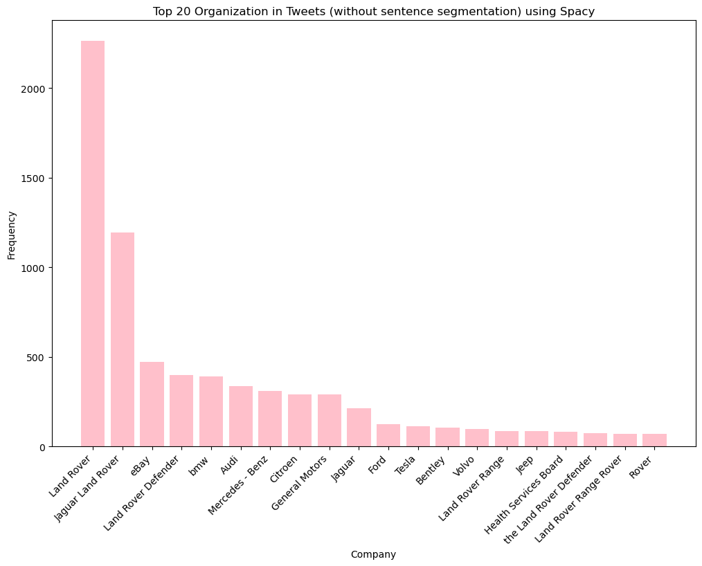

```python
# Assuming top_20_org_cleaned_entities is correctly filled with your data
entity_names, counts = zip(*top_20_org_entities)
# Set the figure size for better readability
plt.figure(figsize=(12, 8))  # Adjusted for vertical orientation
# Create a vertical bar chart
plt.bar(entity_names, counts, color="pink")
# Y-axis label now represents frequency
plt.ylabel('Frequency')
# X-axis label now represents company names
plt.xlabel('Company')
# Title of the plot
plt.title('Top 20 Organization in Tweets (without sentence segmentation) using Spacy')
# Rotate company names for better readability
plt.xticks(rotation=45, ha="right")
# Dislay the plot
plt.show()
```

## Extract entities without sentence segmentation for News

```python
def extract_entities(text):
    doc = nlp(text)
    return [(ent.text, ent.label_) for ent in doc.ents]
```

```python
news_df['entities'] = news_df['cleaned text'].parallel_apply(extract_entities)
```

```python
news_df.head()
```

|  | url | date | language | title | text | cleaned text | cleaned title | entities |
| --- | --- | --- | --- | --- | --- | --- | --- | --- |
| 0 | http://kokomoperspective.com/obituaries/jon-w-horton/article_b6ba8e1e-cb9c-11eb-9868-fb11b88b9778.html | 2021-06-13 | en | Jon W. Horton \| Obituaries \| kokomoperspective.com | Jon W. Horton \| Obituaries \| kokomoperspective.comYou have permission to edit this article. EditCloseSign Up Log In Dashboard LogoutMy Account Dashboard Profile Saved items LogoutCOVID-19Click here … | Jon W. Horton \| Obituaries \| kokomoperspective.comyou have permission to edit this article . editclosesign up log in Dashboard LogoutMy Account Dashboard Profile Saved item LogoutCOVID-19Click here … | Jon W. Horton \| Obituaries \| kokomoperspective.com | [(Jon W. Horton \| Obituaries \|, PERSON), (Dashboard , WORK_OF_ART), (LogoutMy Account Dashboard Profile Saved, ORG), (LogoutCOVID-19Click, ORG), (covid-19HomeAbout UsContact, ORG), (Kokomo, GPE), (4… |
| 1 | https://auto.economictimes.indiatimes.com/news/auto-components/birla-precision-to-ramp-up-capacity-to-tap-emerging-opportunities-in-india/81254902 | 2021-02-28 | en | Birla Precision to ramp up capacity to tap emerging opportunities in India, Auto News, ET Auto | Birla Precision to ramp up capacity to tap emerging opportunities in India, Auto News, ET Auto We have updated our terms and conditions and privacy policy Click "Continue" to accept and continue with … | Birla Precision to ramp up capacity to tap emerge opportunity in India , Auto News , et Auto we have update our term and condition and privacy policy Click " Continue " to accept and continue with et … | Birla Precision to ramp up capacity to tap emerge opportunity in India , Auto News , et Auto | [(Birla Precision, PERSON), (India, GPE), (Auto News, ORG), (et AutoAccept, ORG), (European Union, ORG), (AnalyticsNecessaryNewsletter NameProviderExpiryTypePurpose, PERSON), (Google, ORG), (YearHTTPS… |
| 2 | https://ca.sports.yahoo.com/news/global-hydrogen-fueling-station-markets-104800330.html?src=rss | 2021-12-07 | en | Global Hydrogen Fueling Station Markets to 2035: Current State and Future Prognosis of Passenger Hydrogen Fuel Cell Vehicles (FCVs) | Global Hydrogen Fueling Station Markets to 2035: Current State and Future Prognosis of Passenger Hydrogen Fuel Cell Vehicles (FCVs) HOME MAIL NEWS SPORTS FINANCE CELEBRITY STYLE MOVIES WEATHER MOBILE … | global Hydrogen Fueling Station Markets to 2035 : current State and Future Prognosis of Passenger Hydrogen Fuel Cell Vehicles ( fcv ) home mail news sport finance celebrity style movie weather mobile … | global Hydrogen Fueling Station Markets to 2035 : current State and Future Prognosis of Passenger Hydrogen Fuel Cell Vehicles ( fcv ) | [(Hydrogen Fueling Station Markets, ORG), (2035, CARDINAL), (State, ORG), (Passenger Hydrogen Fuel Cell Vehicles, ORG), (Yahoo Sports Sign, WORK_OF_ART), (Sports Home Sports Home Fantasy Fantasy Fanta… |
| 3 | https://cardealermagazine.co.uk/publish/july-20-backlash-over-covid-passports-cummings-leaks-more-pm-texts-extreme-heat-warning-anniversary-mini-cooper-jcw-revealed/228570 | 2021-07-20 | en | July 20: Backlash over Covid passports; Cummings leaks more PM texts; Extreme heat warning; Anniversary Mini Cooper JCW revealed – Car Dealer Magazine | July 20: Backlash over Covid passports; Cummings leaks more PM texts; Extreme heat warning; Anniversary Mini Cooper JCW revealed – Car Dealer Magazine Log inCar Dealer Magazine LogoThe logo for Car De… | July 20 : backlash over Covid passport ; Cummings leak more pm text ; extreme heat warning ; Anniversary Mini Cooper jcw reveal – car dealer Magazine Log incar dealer Magazine LogoThe logo for car dea… | July 20 : backlash over Covid passport ; Cummings leak more pm text ; extreme heat warning ; Anniversary Mini Cooper jcw reveal – car dealer magazine | [(July 20, DATE), (Cummings, PERSON), (Mini Cooper jcw, PRODUCT), (Magazine Log, ORG), (LogoThe, ORG), (Magazine Log, ORG), (GuideLatest, PERSON), (100home, DATE), (July 20, DATE), (Cummings, PERSON),… |
| 4 | https://fox5sandiego.com/news/local-news/nonprofit-threatens-lawsuit-over-whales-found-dead-at-naval-base-san-diego/ | 2021-05-17 | en | Nonprofit threatens lawsuit over whales found dead at Naval Base San Diego \| FOX 5 San Diego | Nonprofit threatens lawsuit over whales found dead at Naval Base San Diego \| FOX 5 San DiegoSkip to contentFOX 5 San DiegoSan Diego65°Sponsored By Toggle MenuOpen NavigationClose NavigationSearchPrim… | Nonprofit threaten lawsuit over whale find dead at Naval Base San Diego \| fox 5 San DiegoSkip to contentfox 5 San DiegoSan Diego65 ° sponsor by Toggle MenuOpen NavigationClose NavigationSearchPrimary… | Nonprofit threaten lawsuit over whale find dead at Naval Base San Diego \| fox 5 San Diego | [(Naval Base San Diego \|, FAC), (5, CARDINAL), (San DiegoSkip, PERSON), (5, CARDINAL), (San DiegoSan Diego65 °, GPE), (Toggle, ORG), (NavigationClose, PERSON), (5, CARDINAL), (5, CARDINAL), (AppsEmai… |

```python
# Flatten the entities list, filter by "ORG", and count occurrences
org_entities = [entity for sublist in news_df['entities'] for entity in sublist if entity[1] == 'ORG']
org_text_counts = Counter([entity[0] for entity in org_entities])

# Get the top 20 most common "ORG" entities
top_20_org_entities = org_text_counts.most_common(20)

print(top_20_org_entities)
```

```
[('Facebook', 9242), ('Ford', 7607), ('Netflix', 7179), ('Toyota', 6099), ('covid-19', 4511), ('Hyundai', 4350), ('Amazon', 4060), ('Honda', 3990), ('Land Rover', 3464), ('Instagram', 3213), ('Chevrolet', 3020), ("Prince Philip 's", 2969), ('bmw', 2930), ('Tesla', 2879), ('Nissan', 2707), ('Apple', …
```

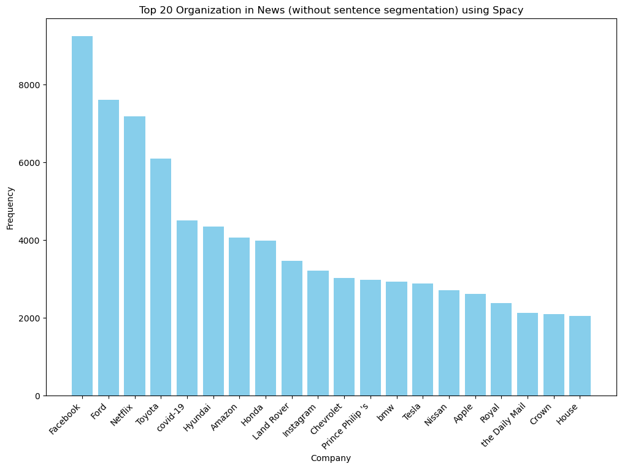

```python
entity_names, counts = zip(*top_20_org_entities)
plt.figure(figsize=(12, 8))  # Adjusted for vertical orientation
plt.bar(entity_names, counts, color="skyblue")
plt.ylabel('Frequency')
plt.xlabel('Company')
plt.title('Top 20 Organization in News (without sentence segmentation) using Spacy')
plt.xticks(rotation=45, ha="right")
plt.show()
```

## For News' title

```python
news_df.head(2)
```

[output not shown]

```python
def extract_entities(text):
    doc = nlp(text)
    return [(ent.text, ent.label_) for ent in doc.ents]
```

```python
# Flatten the entities list, filter by "ORG", and count occurrences
org_entities = [entity for sublist in news_df['title entities'] for entity in sublist if entity[1] == 'ORG']
org_text_counts = Counter([entity[0] for entity in org_entities])

# Get the top 20 most common "ORG" entities
top_20_org_entities = org_text_counts.most_common(20)

print(top_20_org_entities)
```

```
[('| Daily Mail', 851), ('Ford', 359), ('Ontario | carpages.ca', 308), ('Toyota', 203), ('British Columbia |', 198), ('Chevrolet', 197), ('Hyundai', 177), ('Honda', 162), ('| Star News', 128), ('Alberta | Carpages.ca', 114), ('Nissan', 102), ('bmw', 91), ('| Express & Star', 90), ('Auto News', 72), …
```

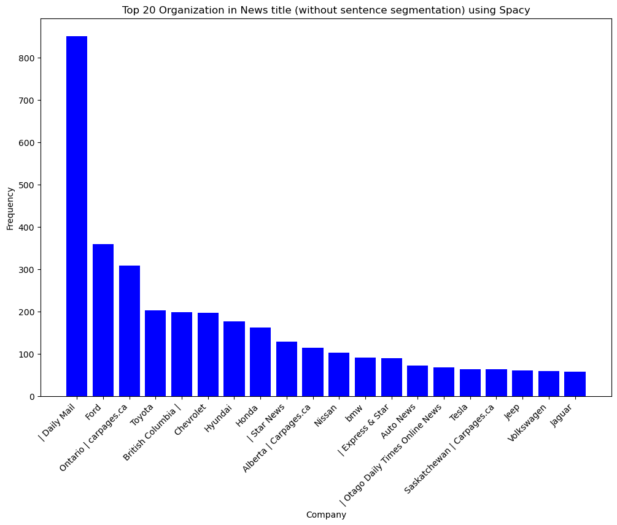

```python
entity_names, counts = zip(*top_20_org_entities)
plt.figure(figsize=(12, 8))  # Adjusted for vertical orientation
plt.bar(entity_names, counts, color="blue")
plt.ylabel('Frequency')
plt.xlabel('Company')
plt.title('Top 20 Organization in News title (without sentence segmentation) using Spacy')
plt.xticks(rotation=45, ha="right")
plt.show()
```

# Extract entities with sentence segmentation for Tweets

```python
def segment_sentences(text):
    doc = nlp(text)
    return [sentence.text.strip() for sentence in doc.sents]
```

```python
tweets_df['segmented sentences'] = tweets_df['cleaned text'].parallel_apply(segment_sentences)
```

```python
tweets_df.head()
```

[output not shown]

```python
def extract_entities_pipe(texts, batch_size=500):
    entities_batch = []
    for doc in nlp.pipe(texts, batch_size=batch_size):
        doc_entities = [(ent.text, ent.label_) for ent in doc.ents]
        entities_batch.append(doc_entities)
    return entities_batch

# Flatten the list of lists into a single list of sentences
flat_list_of_sentences = [sentence for sublist in tweets_df['segmented sentences'] for sentence in sublist]

# Now flat_list_of_sentences is a flat list of strings, as expected
entities_batch = extract_entities_pipe(flat_list_of_sentences)
# This is an illustrative example; actual implementation might vary
# Assume entities_batch is now a list of lists of entities for each sentence
# And we want to associate them back with the original DataFrame's rows

# Initialize an empty list to store entities grouped by original tweets
grouped_entities = []
index = 0

# Iterate over the original list of lists
for sublist in tweets_df['segmented sentences']:
    # For each sublist, aggregate entities from the corresponding number of sentences
    tweet_entities = []
    for _ in sublist:
        tweet_entities.extend(entities_batch[index])
        index += 1
    grouped_entities.append(tweet_entities)

# Now grouped_entities should align with the rows of tweets_df
tweets_df['segmented entities'] = grouped_entities
```

```python
# Flatten the entities list, filter by "ORG", and count occurrences
org_seg_entities = [entity for sublist in tweets_df['segmented entities'] for entity in sublist if entity[1] == 'ORG']
org_seg_text_counts = Counter([entity[0] for entity in org_seg_entities])

# Get the top 20 most common "ORG" entities
top_20_org_seg_entities = org_seg_text_counts.most_common(20)

print(top_20_org_seg_entities)
```

```
[('Land Rover', 2311), ('Jaguar Land Rover', 1193), ('eBay', 471), ('Land Rover Defender', 408), ('bmw', 393), ('Audi', 339), ('Mercedes - Benz', 311), ('Citroen', 292), ('General Motors', 291), ('Jaguar', 213), ('Ford', 126), ('Tesla', 115), ('Bentley', 112), ('Volvo', 98), ('Jeep', 87), ('Land Rov…
```

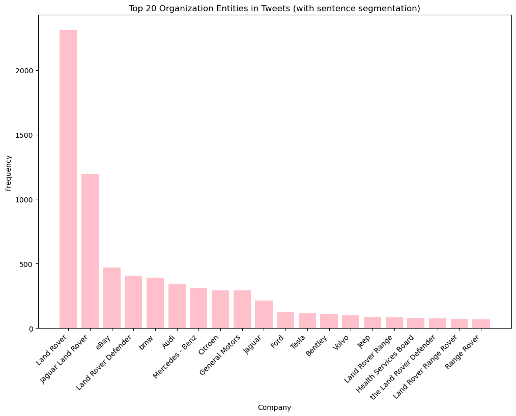

```python
# Assuming entity_names and counts have been defined as before
entity_names, counts = zip(*top_20_org_seg_entities)  # Unzipping names and counts

plt.figure(figsize=(12, 8))  # Adjust figure size as needed for vertical orientation
plt.bar(entity_names, counts, color="pink")  # Create a vertical bar chart
plt.ylabel('Frequency')  # Y-axis label now represents frequency
plt.xlabel('Company')  # X-axis label now represents company names
plt.title('Top 20 Organization Entities in Tweets (with sentence segmentation)')  # Title of the plot
plt.xticks(rotation=45, ha="right")  # Rotate company names for better readability
plt.show()
```

## Plot above is our final result. We found analysis on Tweets data using Spacy and sentences segmentation is our best solution to find out most relevent company names. We also found that there's no significant difference between output obtained from sentences segmentation and without sentences segmentation.

# Extract entities with sentence segmentation for News

```python
def segment_sentences(text):
    doc = nlp(text)
    return [sentence.text.strip() for sentence in doc.sents]
```

```python
news_df['segmented sentences'] = news_df['cleaned text'].parallel_apply(segment_sentences)
```

```python
def extract_entities_pipe(texts, batch_size=500):
    entities_batch = []
    for doc in nlp.pipe(texts, batch_size=batch_size):
        doc_entities = [(ent.text, ent.label_) for ent in doc.ents]
        entities_batch.append(doc_entities)
    return entities_batch

# Flatten the list of lists into a single list of sentences
flat_list_of_sentences = [sentence for sublist in news_df['segmented sentences'] for sentence in sublist]

# Now flat_list_of_sentences is a flat list of strings, as expected
entities_batch = extract_entities_pipe(flat_list_of_sentences)
# This is an illustrative example; actual implementation might vary
# Assume entities_batch is now a list of lists of entities for each sentence
# And we want to associate them back with the original DataFrame's rows

# Initialize an empty list to store entities grouped by original tweets
grouped_entities = []
index = 0

# Iterate over the original list of lists
for sublist in news_df['segmented sentences']:
    # For each sublist, aggregate entities from the corresponding number of sentences
    news_df_entities = []
    for _ in sublist:
        news_df_entities.extend(entities_batch[index])
        index += 1
    grouped_entities.append(news_df_entities)

# Now grouped_entities should align with the rows of tweets_df
news_df['segmented entities'] = grouped_entities
```

```python
# Flatten the entities list, filter by "ORG", and count occurrences
org_seg_entities = [entity for sublist in news_df['segmented entities'] for entity in sublist if entity[1] == 'ORG']
org_seg_text_counts = Counter([entity[0] for entity in org_seg_entities])

# Get the top 20 most common "ORG" entities
top_20_org_seg_entities = org_seg_text_counts.most_common(20)

print(top_20_org_seg_entities)
```

```
[('Facebook', 9236), ('Ford', 7458), ('Netflix', 7188), ('Toyota', 6143), ('covid-19', 4512), ('Hyundai', 4346), ('Amazon', 4064), ('Honda', 3996), ("Prince Philip 's", 3528), ('Land Rover', 3444), ('Instagram', 3381), ('Tesla', 3067), ('Chevrolet', 3037), ('bmw', 2964), ('Nissan', 2760), ('Apple', …
```

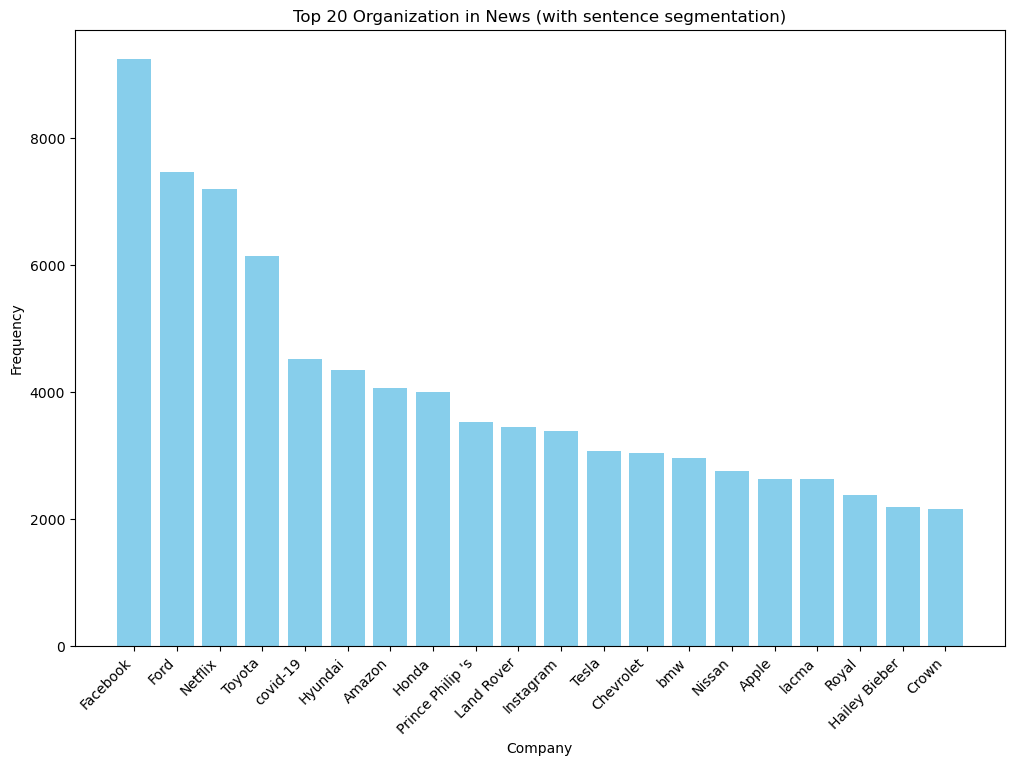

```python
# Assuming entity_names and counts have been defined as before
entity_names, counts = zip(*top_20_org_seg_entities)  # Unzipping names and counts

plt.figure(figsize=(12, 8))  # Adjust figure size as needed for vertical orientation
plt.bar(entity_names, counts, color="skyblue")  # Create a vertical bar chart
plt.ylabel('Frequency')  # Y-axis label now represents frequency
plt.xlabel('Company')  # X-axis label now represents company names
plt.title('Top 20 Organization in News (with sentence segmentation)')  # Title of the plot
plt.xticks(rotation=45, ha="right")  # Rotate company names for better readability
plt.show()
```

## For News data, even though Land Rover, which we found the most relevent company name in Tweets, is not that dominant as it is in Tweets data, we figured out that Land Rover could also be labeled as "PRODUCT" by Spacy and therefore decreased our analysis accuracy. Based on this consideration, we still prioritize the company name as Land Rover as we found in Tweets data, because we believe tweets data is not large as News data, so it's not complicated to handle it.

# For News' title

```python
news_df['segmented title'] = news_df['cleaned title'].parallel_apply(segment_sentences)
```

```python
# Flatten the list of lists into a single list of sentences
flat_list_of_sentences = [sentence for sublist in news_df['segmented title'] for sentence in sublist]

# Now flat_list_of_sentences is a flat list of strings, as expected
entities_batch = extract_entities_pipe(flat_list_of_sentences)
# This is an illustrative example; actual implementation might vary
# Assume entities_batch is now a list of lists of entities for each sentence
# And we want to associate them back with the original DataFrame's rows

# Initialize an empty list to store entities grouped by original tweets
grouped_entities = []
index = 0

# Iterate over the original list of lists
for sublist in news_df['segmented title']:
    # For each sublist, aggregate entities from the corresponding number of sentences
    news_entities = []
    for _ in sublist:
        news_entities.extend(entities_batch[index])
        index += 1
    grouped_entities.append(news_entities)

# Now grouped_entities should align with the rows of tweets_df
news_df['segmented title entities'] = grouped_entities
```

```python
# Flatten the entities list, filter by "ORG", and count occurrences
org_seg_entities = [entity for sublist in news_df['segmented title entities'] for entity in sublist if entity[1] == 'ORG']
org_seg_text_counts = Counter([entity[0] for entity in org_seg_entities])

# Get the top 20 most common "ORG" entities
top_20_org_seg_entities = org_seg_text_counts.most_common(20)

print(top_20_org_seg_entities)
```

```
[('| Daily Mail', 866), ('Daily Mail', 446), ('Ford', 359), ('Ontario | carpages.ca', 308), ('Toyota', 204), ('Chevrolet', 197), ('British Columbia |', 195), ('Hyundai', 177), ('Honda', 162), ('| Star News', 131), ('Alberta | Carpages.ca', 114), ('Nissan', 102), ('bmw', 92), ('| Express & Star', 91)…
```

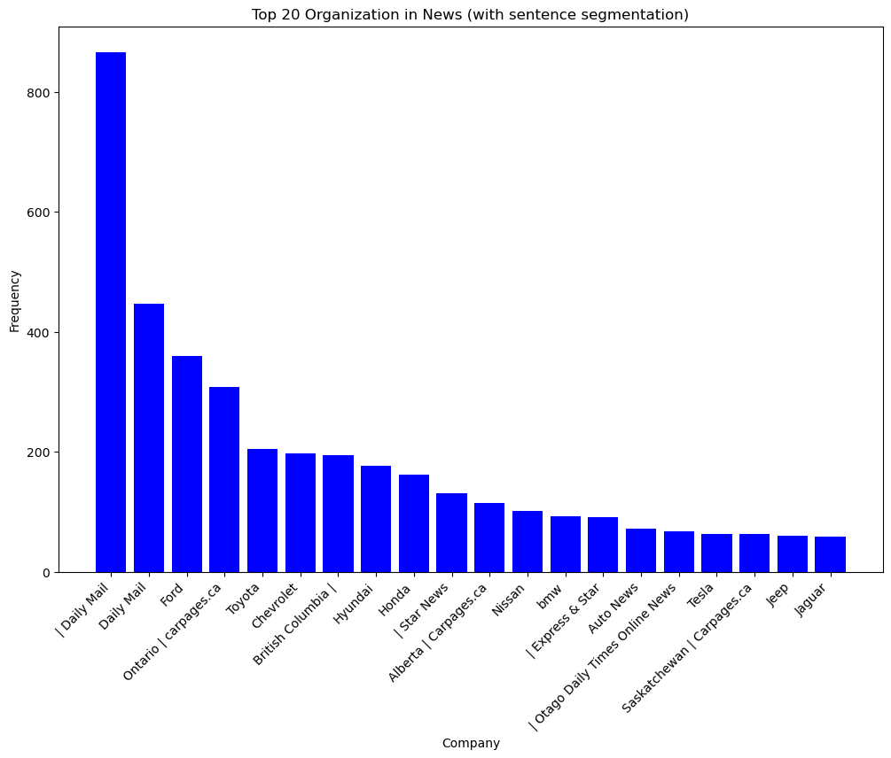

```python
# Assuming entity_names and counts have been defined as before
entity_names, counts = zip(*top_20_org_seg_entities)  # Unzipping names and counts

plt.figure(figsize=(12, 8))  # Adjust figure size as needed for vertical orientation
plt.bar(entity_names, counts, color="blue")  # Create a vertical bar chart
plt.ylabel('Frequency')  # Y-axis label now represents frequency
plt.xlabel('Company')  # X-axis label now represents company names
plt.title('Top 20 Organization in News (with sentence segmentation)')  # Title of the plot
plt.xticks(rotation=45, ha="right")  # Rotate company names for better readability
plt.show()
```

## We found anaysis on News' title with the same technique could lead to least accuracy as the plot showed above.

# Q2: Identify what other companies are most frequently mentioned along with your primary company

## Our primary company is Land Rover

## In Tweets

```python
from collections import Counter


# Initialize a Counter object to count mentions of other companies
other_companies_counts = Counter()
primary_company = 'Land Rover'
# Iterate through each row in the DataFrame
for entities in tweets_df['entities']:
    # Check if the primary company is mentioned in the current document's entities
    if any(primary_company in entity for entity, label in entities if label == 'ORG'):
        # Filter for other organization entities in this document
        other_companies = [entity for entity, label in entities if label == 'ORG' and primary_company not in entity]
        # Update counts for other companies mentioned in the same document
        other_companies_counts.update(other_companies)

# Get the most common companies mentioned alongside the primary company
most_common_companies = other_companies_counts.most_common(10)

# Display the results
print(f"Companies most frequently mentioned with {primary_company}:")
for company, count in most_common_companies:
    print(f"{company}: {count} times")
```

```
Companies most frequently mentioned with Land Rover:
bmw: 346 times
Audi: 329 times
Mercedes - Benz: 299 times
General Motors: 291 times
Citroen: 289 times
Jaguar: 150 times
eBay: 149 times
Tesla: 92 times
Bentley: 90 times
Jeep: 77 times
```

## In News

```python
from collections import Counter


# Initialize a Counter object to count mentions of other companies
other_companies_counts = Counter()
primary_company = 'Land Rover'
# Iterate through each row in the DataFrame
for entities in news_df['entities']:
    # Check if the primary company is mentioned in the current document's entities
    if any(primary_company in entity for entity, label in entities if label == 'ORG'):
        # Filter for other organization entities in this document
        other_companies = [entity for entity, label in entities if label == 'ORG' and primary_company not in entity]
        # Update counts for other companies mentioned in the same document
        other_companies_counts.update(other_companies)

# Get the most common companies mentioned alongside the primary company
most_common_companies = other_companies_counts.most_common(10)

# Display the results
print(f"Companies most frequently mentioned with {primary_company}:")
for company, count in most_common_companies:
    print(f"{company}: {count} times")
```

```
Companies most frequently mentioned with Land Rover:
Facebook: 6692 times
Netflix: 5371 times
Amazon: 2709 times
covid-19: 2544 times
Instagram: 2216 times
Ford: 2193 times
Prince Philip 's: 2132 times
Palace: 1944 times
Apple: 1920 times
Royal: 1723 times
```

# Q3: Identify most frequent locations of events, by extracting appropriate named entities. Locations may include countries, states, cities, regions, etc.

## Location for Tweets

```python
# Filter out location entities
tweets_location = [entity[0] for row in tweets_df['entities'] for entity in row if entity[1] in ['GPE', 'LOC', 'FAC']]
```

```python
location_counts = Counter(tweets_location)
most_common_locations = location_counts.most_common(20)
for location, count in most_common_locations:
    print(f"{location}: {count}")
```

```
Russia: 183
uk: 150
Zimbabwe: 118
India: 94
Cambridge: 85
BaT: 82
Britain: 65
Jamaica: 59
Sussex: 51
Netherlands: 41
Brunswick Sq: 40
weekchase: 40
London: 37
China: 36
Zuiderpark the Hague: 27
Bridgwater: 27
South Africa: 26
France: 26
New Zealand: 25
Hollywood: 24
```

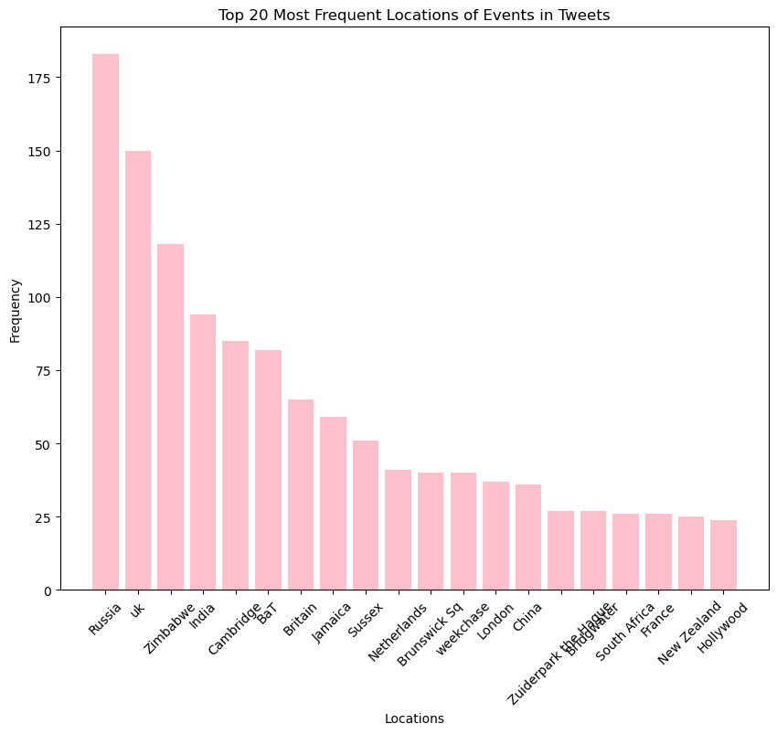

```python
# Unpack the most common locations for plotting
locations, counts = zip(*most_common_locations)

# Create a bar chart
plt.figure(figsize=(10, 8))
plt.bar(locations, counts, color='pink')
plt.xlabel('Locations')
plt.ylabel('Frequency')
plt.title('Top 20 Most Frequent Locations of Events in Tweets')
plt.xticks(rotation=45)
plt.show()
```

## Location for News

```python
# Filter out location entities
news_location = [entity[0] for row in news_df['entities'] for entity in row if entity[1] in ['GPE', 'LOC', 'FAC']]
```

```python
location_counts = Counter(news_location)
most_common_locations = location_counts.most_common(20)
for location, count in most_common_locations:
    print(f"{location}: {count}")
```

```
London: 10251
Los Angeles: 9908
New York City: 6316
Hollywood: 6017
uk: 5815
West Hollywood: 5588
Miami: 5416
Australia: 5225
India: 5077
nyc: 4982
California: 4542
Paris: 4494
Sydney: 4326
New York: 4014
China: 3906
Britain: 3900
Beverly Hills: 3857
Edinburgh: 3762
U.S.: 3612
Malibu: 3498
```

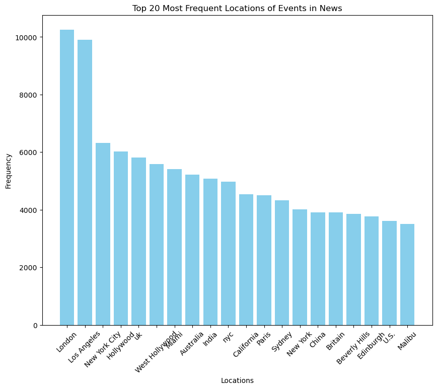

```python
# Unpack the most common locations for plotting
locations, counts = zip(*most_common_locations)

# Create a bar chart
plt.figure(figsize=(10, 8))
plt.bar(locations, counts, color='skyblue')
plt.xlabel('Locations')
plt.ylabel('Frequency')
plt.title('Top 20 Most Frequent Locations of Events in News')
plt.xticks(rotation=45)
plt.show()
```

# Below showed NLTK method

## Put the summary ahead, we found the performance of NLTK method didn't overtake Spacy from the ouput.

## And also there's no significant difference between output obtained from those with sentences segmentation and those without sentences segmentation.

## Using NLTK to analyze on Tweets has quite similar results as to using Spacy; but the analysis output obtained from News data using NLTK is quite different from it is used with Spacy.

# Extract entities without sentence segmentation for Tweets

```python
import nltk
from nltk.tokenize import word_tokenize
from nltk.tag import pos_tag
from nltk.chunk import ne_chunk
nltk.download('punkt')
nltk.download('maxent_ne_chunker')
nltk.download('words')
nltk.download('averaged_perceptron_tagger')

def extract_entities(text):
    # Tokenize the text into words
    tokens = word_tokenize(text)
    # Part-of-speech tagging
    tagged = pos_tag(tokens)
    # Named entity recognition
    entities_tree = ne_chunk(tagged)

    # Extract entities
    entities = []
    for subtree in entities_tree:
        if hasattr(subtree, 'label'):
            entity = " ".join(word for word, tag in subtree.leaves())
            entities.append((entity, subtree.label()))
    return entities
```

```python
# Apply the batch processing function
tweets_df['NLTK_entities'] = tweets_df['cleaned text'].parallel_apply(extract_entities)
```

```python
tweets_df.head()
```

|  | id | lang | date | name | retweeted | text | cleaned text | entities | NLTK_entities |
| --- | --- | --- | --- | --- | --- | --- | --- | --- | --- |
| 0 | 1534565117614084096 | en | 2022-06-08 | Low Orbit Tourist 🌍📷 |  | Body &amp; Assembly - Halewood - United Kingdom\n🌍53.3504,-2.8352296,402m\n\nHalewood Body &amp; Assembly is a Jaguar Land Rover factory in Halewood, England, and forms the major part of the Halewood … | body & amp ; Assembly - Halewood - United Kingdom 53.3504,-2.8352296,402 m Halewood Body & amp ; Assembly be a Jaguar Land Rover factory in Halewood , England , and form the major part of the Halewood… | [(body & amp, ORG), (Assembly - Halewood - United Kingdom, ORG), (53.3504,-2.8352296,402 m, QUANTITY), (Halewood Body & amp, ORG), (Assembly, ORG), (Jaguar Land Rover, ORG), (Halewood, GPE), (England,… | [(Assembly, ORGANIZATION), (Halewood, GPE), (United, GPE), (Halewood Body, PERSON), (Jaguar Land, ORGANIZATION), (Halewood, GPE), (England, GPE), (Halewood, ORGANIZATION)] |
| 1 | 1534565743429394439 | en | 2022-06-08 | CompleteCar.ie | RT | Land Rover Ireland has announced that the new Range Rover Sport starts at €114,150, now on @completecar:\n\nhttps://t.co/TjGUkL3FYr https://t.co/QdVaEiJkjO | Land Rover Ireland have announce that the new Range Rover Sport start at € 114,150 , now on : | [(Land Rover Ireland, ORG), (Range Rover Sport, ORG), (114,150, MONEY)] | [(Land, GPE), (Rover Ireland, PERSON), (Range Rover Sport, PERSON)] |
| 2 | 1529341557580652545 | en | 2022-05-25 | Exmoor Trim |  | New Land Rover Range Rover Hits Top Speed With Ease On Autobahn\n\nhttps://t.co/19QOgAIu3v | New Land Rover Range Rover Hits Top Speed with ease on Autobahn | [(New Land Rover Range Rover Hits Top Speed, ORG), (Autobahn, FAC)] | [(New Land, GPE), (Range Rover Hits Top Speed, PERSON)] |
| 3 | 1542790343535755264 | en | 2022-07-01 | Land Rover UK |  | @BeckyWatts1 Hi, thank you for your post. I am sorry to learn of your retailer experience, however when order slots are available they will be presented to the retailer, and it is at their discretion … | hi , thank you for your post . I be sorry to learn of your retailer experience , however when order slot be available they will be present to the retailer , and it be at their discretion which vehicle… | [(Dan - Land, PERSON)] | [(Dan, GPE), (Land, GPE)] |
| 4 | 1516732103370493954 | en | 2022-04-20 | Sussexes❤️👑🐼🌸 |  | @cofvefe917 @Mackingday No this was during the Land Rover driving challenge. | no this be during the Land Rover drive challenge . | [(Land Rover, ORG)] | [(Land Rover, ORGANIZATION)] |

```python
# Flatten the entities list, filter by "ORG", and count occurrences
org_entities = [entity for sublist in tweets_df['NLTK_entities'] for entity in sublist if entity[1] == 'ORGANIZATION']
org_text_counts = Counter([entity[0] for entity in org_entities])

# Get the top 20 most common "ORG" entities
top_20_org_entities = org_text_counts.most_common(20)

print(top_20_org_entities)
```

```
[('Land Rover', 1465), ('Land', 762), ('Mercedes', 338), ('Land Rover Discovery', 337), ('eBay', 308), ('General Motors', 299), ('Duke', 191), ('Duchess', 174), ('Jaguar Land Rover', 132), ('Jaguar Land', 114), ('Land Rover Defender', 100), ('BaT', 82), ('Queen', 78), ('Paracetamol', 64), ('BR19', 6…
```

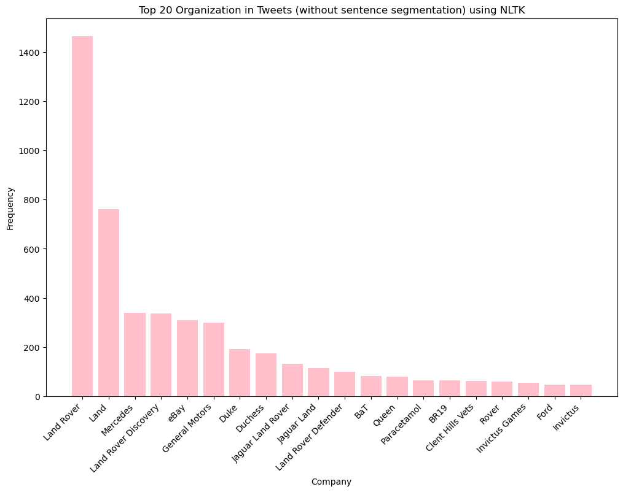

```python
# Assuming entity_names and counts have been defined as before
entity_names, counts = zip(*top_20_org_entities)  # Unzipping names and counts

plt.figure(figsize=(12, 8))  # Adjust figure size as needed for vertical orientation
plt.bar(entity_names, counts, color="pink")  # Create a vertical bar chart
plt.ylabel('Frequency')  # Y-axis label now represents frequency
plt.xlabel('Company')  # X-axis label now represents company names
plt.title('Top 20 Organization in Tweets (without sentence segmentation) using NLTK')  # Title of the plot
plt.xticks(rotation=45, ha="right")  # Rotate company names for better readability
plt.show()
```

# Extract entities without sentence segmentation for News

```python
# Apply the batch processing function
news_df['NLTK_entities'] = news_df['cleaned text'].parallel_apply(extract_entities)
```

```python
# Flatten the entities list, filter by "ORG", and count occurrences
org_entities = [entity for sublist in news_df['NLTK_entities'] for entity in sublist if entity[1] == 'ORGANIZATION']
org_text_counts = Counter([entity[0] for entity in org_entities])

# Get the top 20 most common "ORG" entities
top_20_org_entities = org_text_counts.most_common(20)

print(top_20_org_entities)
```

```
[('MailOnline', 8826), ('Duke', 4931), ('House', 3929), ('Duchess', 3808), ('Princess Diana', 3616), ('Queen', 3577), ('Mercedes', 2726), ('Kate', 2700), ('Prince Philip', 2698), ('Conditions', 2346), ('Prince Harry', 2263), ('Kate Middleton', 2250), ('Daily Mail', 2145), ('RomeoAston', 2109), ('Pri…
```

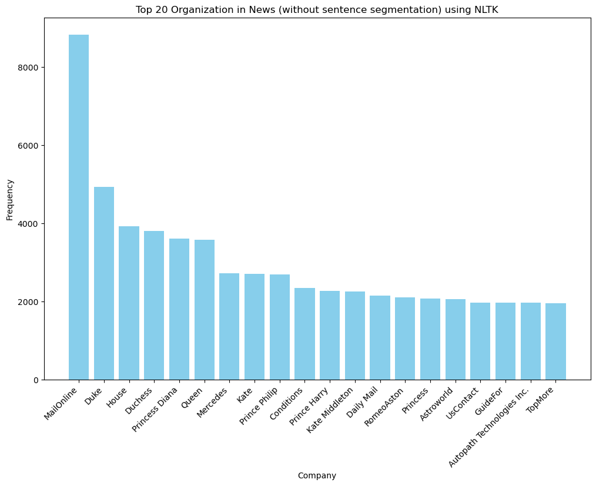

```python
# Assuming entity_names and counts have been defined as before
entity_names, counts = zip(*top_20_org_entities)  # Unzipping names and counts

plt.figure(figsize=(12, 8))  # Adjust figure size as needed for vertical orientation
plt.bar(entity_names, counts, color="skyblue")  # Create a vertical bar chart
plt.ylabel('Frequency')  # Y-axis label now represents frequency
plt.xlabel('Company')  # X-axis label now represents company names
plt.title('Top 20 Organization in News (without sentence segmentation) using NLTK')  # Title of the plot
plt.xticks(rotation=45, ha="right")  # Rotate company names for better readability
plt.show()
```

# For News' title

```python
news_df['NLTK_title_entities'] = news_df['cleaned title'].parallel_apply(extract_entities)
```

```python
# Flatten the entities list, filter by "ORG", and count occurrences
org_entities = [entity for sublist in news_df['NLTK_title_entities'] for entity in sublist if entity[1] == 'ORGANIZATION']
org_text_counts = Counter([entity[0] for entity in org_entities])

# Get the top 20 most common "ORG" entities
top_20_org_entities = org_text_counts.most_common(20)

print(top_20_org_entities)
```

```
[('Daily Mail Online', 421), ('AutoSpies Auto News', 145), ('Mercedes', 103), ('CoventryLive', 97), ('NewsBreak', 82), ('Record', 54), ('Automotive News', 46), ('Hindu', 42), ('News', 37), ('Fast Lane', 34), ('CarWale', 29), ('Prince Philip', 29), ('Business', 26), ('Philip', 25), ('Star News', 23),…
```

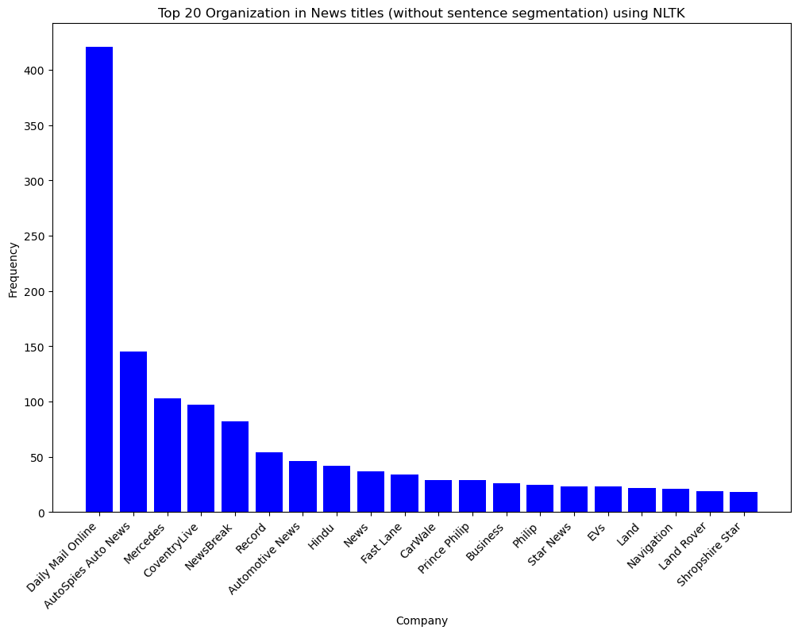

```python
# Assuming entity_names and counts have been defined as before
entity_names, counts = zip(*top_20_org_entities)  # Unzipping names and counts

plt.figure(figsize=(12, 8))  # Adjust figure size as needed for vertical orientation
plt.bar(entity_names, counts, color="blue")  # Create a vertical bar chart
plt.ylabel('Frequency')  # Y-axis label now represents frequency
plt.xlabel('Company')  # X-axis label now represents company names
plt.title('Top 20 Organization in News titles (without sentence segmentation) using NLTK')  # Title of the plot
plt.xticks(rotation=45, ha="right")  # Rotate company names for better readability
plt.show()
```

# Extract entities with sentence segmentation for Tweets

```python
from nltk.tokenize import sent_tokenize

def extract_entities_with_sentences(text):
    entities = []
    # Sentence segmentation
    sentences = sent_tokenize(text)
    for sentence in sentences:
        # Tokenize the sentence into words
        tokens = word_tokenize(sentence)
        # Part-of-speech tagging
        tagged = pos_tag(tokens)
        # Named entity recognition
        entities_tree = ne_chunk(tagged)

        for subtree in entities_tree:
            if hasattr(subtree, 'label'):
                entity = " ".join(word for word, tag in subtree.leaves())
                entities.append((entity, subtree.label()))
    return entities
```

```python
tweets_df['NLTK_seg_entities'] = tweets_df['cleaned text'].parallel_apply(extract_entities_with_sentences)
```

```python
# Flatten the entities list, filter by "ORG", and count occurrences
org_seg_entities = [entity for sublist in tweets_df['NLTK_seg_entities'] for entity in sublist if entity[1] == 'ORGANIZATION']
org_seg_text_counts = Counter([entity[0] for entity in org_seg_entities])

# Get the top 20 most common "ORG" entities
top_20_org_seg_entities = org_seg_text_counts.most_common(20)
print(top_20_org_seg_entities)
```

```
[('Land Rover', 1468), ('Land', 779), ('Land Rover Discovery', 337), ('Mercedes', 326), ('eBay', 308), ('General Motors', 299), ('Duke', 191), ('Duchess', 174), ('Jaguar Land Rover', 132), ('Jaguar Land', 114), ('Land Rover Defender', 100), ('Rover', 91), ('BaT', 82), ('Queen', 78), ('Paracetamol', …
```

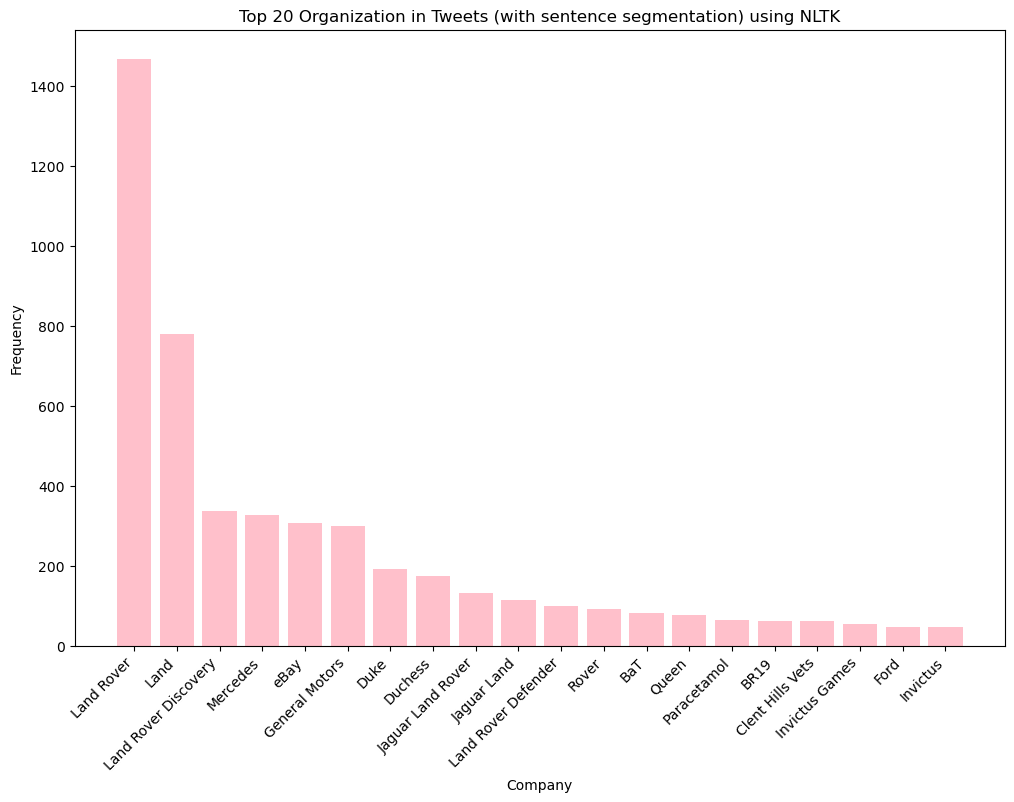

```python
# Assuming entity_names and counts have been defined as before
entity_names, counts = zip(*top_20_org_seg_entities)  # Unzipping names and counts

plt.figure(figsize=(12, 8))  # Adjust figure size as needed for vertical orientation
plt.bar(entity_names, counts, color="pink")  # Create a vertical bar chart
plt.ylabel('Frequency')  # Y-axis label now represents frequency
plt.xlabel('Company')  # X-axis label now represents company names
plt.title('Top 20 Organization in Tweets (with sentence segmentation) using NLTK')  # Title of the plot
plt.xticks(rotation=45, ha="right")  # Rotate company names for better readability
plt.show()
```

# Extract entities with sentence segmentation for News

```python
news_df['NLTK_seg_entities'] = news_df['cleaned text'].parallel_apply(extract_entities_with_sentences)
```

```python
# Flatten the entities list, filter by "ORG", and count occurrences
org_seg_entities = [entity for sublist in news_df['NLTK_seg_entities'] for entity in sublist if entity[1] == 'ORGANIZATION']
org_seg_text_counts = Counter([entity[0] for entity in org_seg_entities])

# Get the top 20 most common "ORG" entities
top_20_org_seg_entities = org_seg_text_counts.most_common(20)
print(top_20_org_seg_entities)
```

```
[('MailOnline', 8816), ('Duke', 4933), ('House', 4050), ('Duchess', 3808), ('Queen', 3578), ('Princess Diana', 3541), ('Prince Philip', 2698), ('Kate', 2677), ('Mercedes', 2665), ('Princess', 2544), ('Conditions', 2346), ('Prince Harry', 2263), ('Kate Middleton', 2169), ('Daily Mail', 2145), ('Romeo…
```

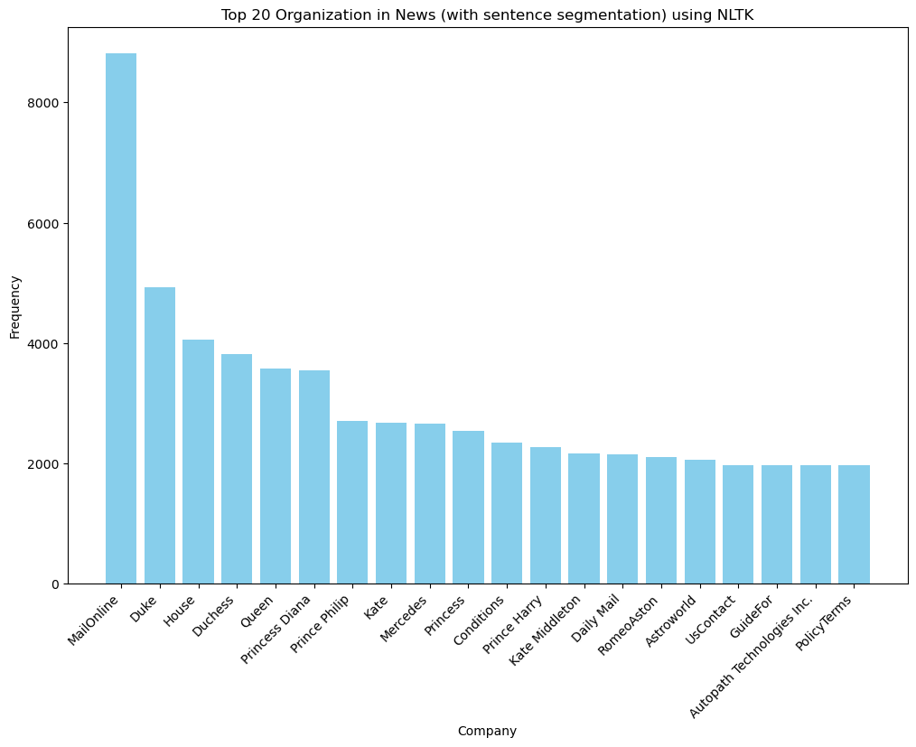

```python
# Assuming entity_names and counts have been defined as before
entity_names, counts = zip(*top_20_org_seg_entities)  # Unzipping names and counts

plt.figure(figsize=(12, 8))  # Adjust figure size as needed for vertical orientation
plt.bar(entity_names, counts, color="skyblue")  # Create a vertical bar chart
plt.ylabel('Frequency')  # Y-axis label now represents frequency
plt.xlabel('Company')  # X-axis label now represents company names
plt.title('Top 20 Organization in News (with sentence segmentation) using NLTK')  # Title of the plot
plt.xticks(rotation=45, ha="right")  # Rotate company names for better readability
plt.show()
```

# For News' title

```python
news_df['NLTK_seg_title_entities'] = news_df['cleaned title'].parallel_apply(extract_entities_with_sentences)
```

```python
# Flatten the entities list, filter by "ORG", and count occurrences
org_seg_entities = [entity for sublist in news_df['NLTK_seg_title_entities'] for entity in sublist if entity[1] == 'ORGANIZATION']
org_seg_text_counts = Counter([entity[0] for entity in org_seg_entities])

# Get the top 20 most common "ORG" entities
top_20_org_seg_entities = org_seg_text_counts.most_common(20)
print(top_20_org_seg_entities)
```

```
[('Daily Mail Online', 397), ('AutoSpies Auto News', 145), ('Mercedes', 102), ('CoventryLive', 97), ('NewsBreak', 82), ('Record', 54), ('Automotive News', 46), ('Hindu', 42), ('News', 36), ('Fast Lane', 34), ('CarWale', 29), ('Prince Philip', 29), ('Business', 26), ('Philip', 25), ('Star News', 24),…
```

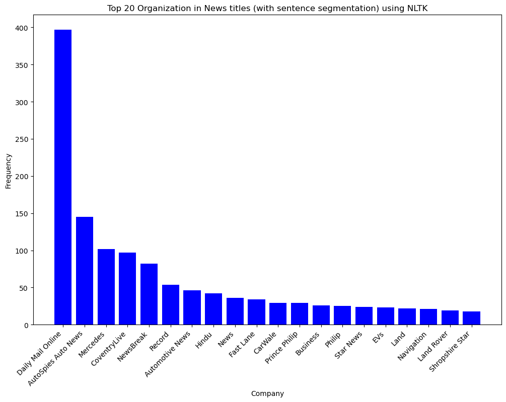

```python
# Assuming entity_names and counts have been defined as before
entity_names, counts = zip(*top_20_org_seg_entities)  # Unzipping names and counts

plt.figure(figsize=(12, 8))  # Adjust figure size as needed for vertical orientation
plt.bar(entity_names, counts, color="blue")  # Create a vertical bar chart
plt.ylabel('Frequency')  # Y-axis label now represents frequency
plt.xlabel('Company')  # X-axis label now represents company names
plt.title('Top 20 Organization in News titles (with sentence segmentation) using NLTK')  # Title of the plot
plt.xticks(rotation=45, ha="right")  # Rotate company names for better readability
plt.show()
```